# **Organic Chemistry I**

## *Key Norms by [A. G. Hossion](https://www.researchgate.net/profile/Abu-Gafar-Hossion)*

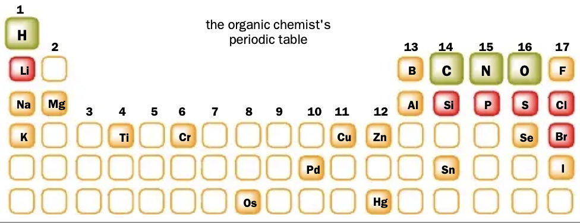

## **Lesson-01, 02, 03.**

## [**Lesson-01_ch01&02**](https://drive.google.com/file/d/1E6LnBULMOB66RxXlqp2ok4QIIHhKi5IN/view?usp=sharing)

### ⏣ *How to read and/or draw bond line and condensed structure of Organic compounds, Functional Groups (FG)*

- **Bond-Line Drawings** : How to read and draw Bond-Line/Condensed structure Drawings?
- **FG**: Identification and naming Functional groups of organic compounds - alkane, alkene, alkyne, alkyl halide, alcohol, ether, thiol, aromatic or arene, ketone, aldehyde, carboxylic acid, acyl halide, anhydride, ester, amide and amine.

### 🍓🍓 Concept Check and/or Mastering the Modality

- Identify the number of carbon atoms and hydrogen atoms in the compounds below, draw condensed or skeletal/line structure:
- identify and label all functional groups in these two compounds:

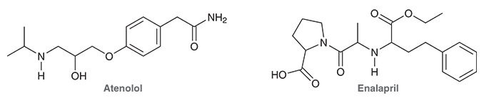

> **Interactive** - [Advanced Functional Group Identifier](https://fgsmiles-gjipew6kusyfvvnajvhjeu.streamlit.app/)

## [**Lesson-02_ch01**](https://drive.google.com/file/d/1JMZvo3VyyUdkymMp0DkYXB73aXNzGFsF/view?usp=sharing)

### ⏣ *Hybrid Atomic Orbitals (AOs), Molecular Orbitals (MOs)*

- **Hybrid atomic orbitals**: Know sp, sp2, sp3 hybrid orbitals. Understand how sigma bond, pi bond, carbon-carbon double bond, carbon-carbon triple bond are form. Know unshared pairs of electron hybridization for oxygen and nitrogen containing compounds. and Steric number.

### 🍓🍓Concept Check and/or Mastering the Modality

- Identify the hybridization state and geometry of each of the carbon, nitrogen and oxygen atoms in following structures, Identify the location of all lone pairs in these compound if not provided:

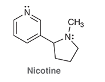

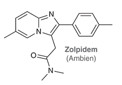

- Rank the indicated bonds in terms of increasing bond length, and Count the total number of Sigma (σ) bonds and Phi(π)bonds in the compounds:

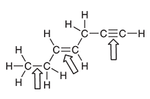

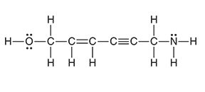

## [**Lesson-03_ch01**](https://drive.google.com/file/d/1VZgkcK9J_lHPaWNXGWTmZ2gh5EE8DpP3/view?usp=sharing)

### ⏣ *Polar and non-Polar Compounds, Dipole moment(µ)*

- **Polar and non-polar covalent bond** : Know the difference covalent bond vs polar covalent bond. Get familiar to identify partial charges vs complete charges.
- **Dipole moment**: What is dipole moment(µ)? Learn how to calculate and draw dipole moment (sign) for a bond (C-Cl, etc) in compounds. Predict molecular geometry on the basis of VSEPR theory. Know how to identify whether compound can exhibit dipole moment and compound is polar or non-polar.
- **Intermolecular forces and physical properties - m.p., b.p., solubility**: What are dipole-dipole interaction, hydrogen bonding, van der Waals forces and/or fleeting dipole-dipole interactions? And understand how these properties change the physical properties of melting point/ boiling point/ Solubility of compounds. Protic/aprotic solvent.

### 🍓🍓Concept Check and/or Mastering the Modality

- Identify whether following molecular exhibit dipole moment or polar covalent bonds. If so, indicate the direction of the net molecular dipole mement.

[figure not shown]

  H<sub>2</sub>O , CH<sub>4</sub>O
- Arrange the following compounds in order of increasing boiling point:

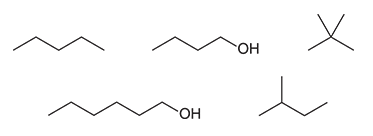

- which of the following protic and aprotic solvent, explain:

[figure not shown]

# **Lesson-04**

# [**Lesson-04_ch02**](https://drive.google.com/file/d/1SQX3NId8a3GpMmyqtVxJ_3a7ZfUt0xAf/view?usp=sharing)

## ⏣ *Resoanace structure and Curved arrow drawing*

- **Formal Charge** : Understand how to identify formal charges in the structure. Know how to calculate formal charges of atoms in the structure.
- **Formal charge on Carbon**: Carbon atoms with formal charges, know Carbocation Vs Carboanion and understand how to identify lone pairs on oxygen and nitrogen atoms.
- **Curved arrow and resonance structure**: understand the five patterns, how to draw right arrow to valid correct resonance structure. (i) Formal charges in resonance structure - allylic (ii) Drawing resonance structure via pattern recognition
- What is **resonance hybrid** and understand **delocalized** and **localized** lone pairs.

### 🍓🍓**Concept Check and/or Mastering the Modality**

- For each of the following carbocation and/or carboanion 'C' identify number of hydrogen, then use that information to determine hybridization state.

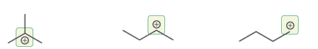

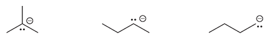

- For each of the following, draw all missing lone pairs or formal charge:

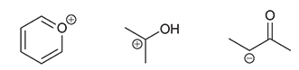

- for each compound below, identify all lone pairs and indicate whether each lone pair is localized or delocalized. Then, use that information (or formal charge) to draw the cuved arrow, all significant resonance and hybrid structures.

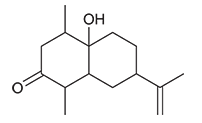

# **Lesson-05**

# [**Lesson-05_ch03**](https://drive.google.com/file/d/1RGTCWb2j_LLXpsC4Gz6HdZrtIEKplXEW/view?usp=sharing)

## ⏣ *Acids and Bases*

- **Acids and Bases**: Know acids and bases definition on the basis of Bronsted-Lowry concept and Lewis concept. Understand how to compare the strength of acids and bases on the basis of structure of molecules (in absence of pKa or pKb values).
- **Lewis Acids and Bases**: Be able to justify Lewis concept is the most fundamental of the acid-base concepts, and the most general; it includes all the other concepts such as Bronsted-Lowry concept. Lewis concept of acidity and basicity fundamental to our understanding of Organic Chemistry.
- **Curved arrow and electron density**: Know how to draw curved arrow to show the flow of electron density and transferring proton.
- **Acidity on the basis of Bronsted-Lowry and Lewis Acids-Bases Concepts**:

  > **Quantitative Perspective**: [pKa and proton transfer ability] Understand how to use pKa to compare acidity and basicity.  
  > **Qualitative Perspective**: Be able to understand the factors such as charge on atoms, resonance, induction, sp/sp2/sp3 orbitals affect the stability of conjugate base. Understand how to compare the strength of acids and bases on the basis of structure of molecules (in absence of pKa or pKb values).  
  > Be able to use **both qualitative and quantitative perspectives** to predict the position of equilibrium in reaction. Organic acid-base mechanism.
- **Leveling and solvent effects and counter-ions**: Understand the strongest base and the strongest acid can be present in any particular solvent such as in a basic solution and/or in an acidic solution.

### 🍓🍓**Concept Check and/or Mastering the Modality**

- Label the **acid** (and/or **Lewis acid**) and **base** (and/or **Lewis base**) reactants, as well as the **conjugate acid** (draw the product sturcture if needed) and **conjugate base** (draw the product sturcture if needed). Draw a mechanism (**curved arrow**) for this acid-base reaction, shown below.

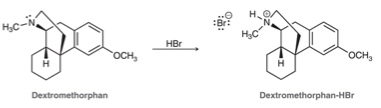

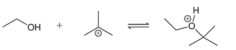

- from each pair of compounds below with using p*K*a values from pka (D. Klein table 3.1) table from your text book identify most **acidic compound** (or most **basic compound**).

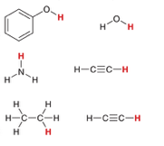

- In each case, identify the stronger base. Explain your choice.

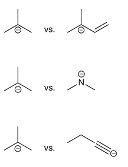

- Without referring to a p*K*a table, identify the most **acidic proton** in each compound below, and arrange most acidic to least acidic:

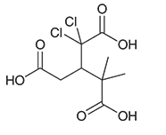

- Without referring to a p*K*a table, rank the following anions in terms of increasing **basicity**, and explain your reasoning:

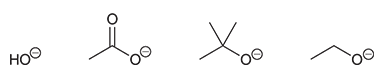

- using or without using p*K*a values from your textbook determine the **position of equilibrium** for each of the following reactions:

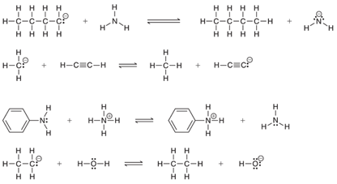

- In each of the following cases, identify whether the reagent shown is suitable to acomplish the task described. Explain why or why not.

[figure not shown]

- Would ethanol (CH<sub>3</sub>CH<sub>2</sub>OH) be a suitable solvent in which to perform the following proton transfer reaction? Explain your answer:

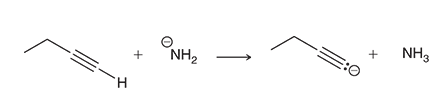

# **Lesson-06, 07**

# [**Lesson-06_ch04**](https://drive.google.com/file/d/1ogTmkq2uAi4y7z4KFAxSvjM5HGGVBnEg/view?usp=sharing)

## ⏣ *Alkane (open chain hydrocarbon, saturated hydrocarbon C<sub>n</sub>H<sub>2n+2</sub>)*

- **IUPAC Naming alkane**: Know how to name saturated hydrocarbon, alkane (both open chain and cyclic).
- **Isomerism**: How to draw constitutional isomers of small molecule.
- **Constitutional isomers**: Know constitutional isomers of alkane and stability of alkanes.
- **Newman projection formula**: Understand how to draw Newman projection formula. Know how to rotate carbon- carbon single bond and understand conformations (eclipsed vs staggered conformations) and torisional strain of saturated hydrocarbon. Be able to identify and compare highest and lowest conformations from structure of molecule.

### 🍓🍓**Concept Check and/or Mastering the Modality**

  > Or draw the line structure from IUPAC naming.

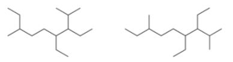

> 2,2,4-Trimethylpentane
- Draw each of the following compounds as a bond-line structure, and then assign IUPAC names for each. Or, assign IUPAC names for each and then Draw a Newman projection of the following compound as viewed from the angle indicated, draw staggered, eclipsed, gauche or anti-gauche (if any) and identy most stable (less energy) vs least stable (high energy).

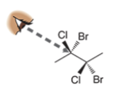

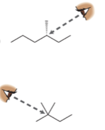

# [**Lesson-07_ch04**](https://drive.google.com/file/d/1fPXa4sDe4vWNTTe3Bv3ncRABBK9KU0ot/view?usp=sharing)

## ⏣ *Cycloalkane (ring-closed chain/bicyclic, saturated cycloalkane C<sub>n</sub>H<sub>2n</sub>)*

- **Naming cycloalkane**: Know the structure of cycloalkane such as single ring cycloalkane general formula C<sub>n</sub>H<sub>2n</sub> and how to name cycloalkane and bicyclic alkane (both open chain and cyclic).
- **Cycloalkane stability**: Understand stability of cycloalkane and how to draw conformation of cyclohexane including axial, equatorial, chair and boat transformation.
- **Geometrical/Stereoisomerism**: *cis*- and *trans*-

### 🍓🍓**Concept Check and/or Mastering the Modality**

- IUPAC name each of the following compound

  > Or, draw bond line structure for each of the following compound.

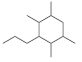

> 1,2,3,4-Tetramethylcycloheptane  
> 2,2,3,3-Tetramethylbicyclo[2.2.1]heptane  
> 8,8-Dimethylbicyclo[3.2.1]octane
- IUPAC name and draw both chair conformations (ring flip) for each of the following compounds.

  > Identify/Draw the lowest energy conformation.

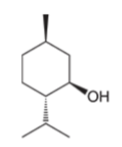

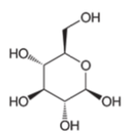

  > Or, For each of the following pairs of compounds, identify the compound that would have the higher heat of combustion (most stable). For the disubstituted cyclohexanes, be sure to evaluate the stability of both possible chair conformations.
- Draw both chair conformations for each of the following compounds. In each case, identify the more stable chair conformation. *trans*-1,2-Diisopropylcyclohexane, *cis*-1,3-Diisopropylcyclohexane, *trans*-1,4-Diisopropylcyclohexane.

# **Lesson-08, 09**

# [**Lesson-08(ch-05)**](https://drive.google.com/file/d/1HMjGuChV33OjO5CB3cO4iBHzxshlKJUt/view?usp=sharing)

## ⏣ *Stereoisomerism - Enantiomers, Optical Activity*

- ***cis*- & *trans*-** : Understand how to draw and identify isomer (*cis*-, and *trans*-) and stereoisomer.
- **Chirality**: Be able to identify chirality center, chiral molecule, achiral molecule, enantiomers.
- **Optically active**: know how experimentally optical activity can be determined. know specific rotation, dextrorotatory and + sign, levorotatory and - sign.
- **Enantiomers**:Be able to draw and identify enantiomers.

> Understand what is racemic modification, enantiometric excess (ee) and be able to calculate optical purity from given enantiomeric data.

> Understand how to identify and configure R- and S- configuration. be able to use R-, S- configuration in IUPAC  
> nomenclature.

### 🍓🍓**Concept Check and/or Mastering the Modality**

- Each of the following compounds possess carbon atoms that are chiral centers. Locate each of these chiral ceneter, identify the number of stereoisomers that are possible for each of the following compounds, draw the enantiomers for reach and identify the absolute configuration.

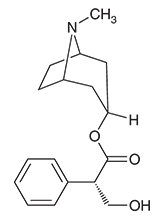

# [**Lesson-09(ch-05)**](https://drive.google.com/file/d/1wbsmqU6_PZ7tz-VD6YdeXQzizYiQV-AT/view?usp=sharing)

## ⏣ *Stereoisomerism - Diastreomers, meso compounds, optical inactive*

- **Optically active vs inactive**:Understand how to identify and distinguish enantiomers, diastereomers and Meso compound. know why enantiomer and meso compound are optically inactive., and diastereomers is optically active.
- ***E*- & *Z*-**: Know *E*- and *Z*- Designations Vs *cis*- and *trans*-.

> Know the resolution of enantiomers.

### 🍓🍓**Concept Check and/or Mastering the Modality**

- For each of the following pairs of drawings, determine the relationship between the two drawings:

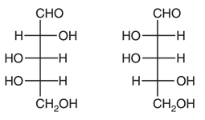

- suggest how to perform a resolution or synthesizing a single enantiomers (so called chiral switch) of following enantiomers.

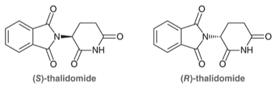

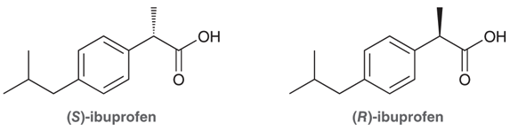

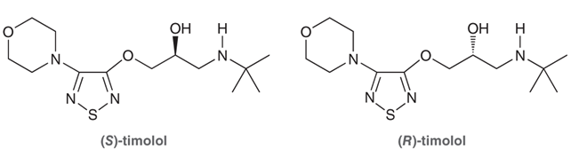